# HW06

```r
## So as it appears, each variable is correlated with itself. And it looks like X100 is related to X110, X400, X400 is related to X1500, poid is related to jave, disq is related to poid. The reason why I think this is because it has a darker color, which by all means they tends to close to 1, which describes that they are related.
```

5. Use base R to create the following four plots.
1. scatterplot of discus(disq) vs shot put(poid)
2. scatterplot of shot put(poid) vs javelin(jave)
3. scatterplot of discus(disq) vs javelin(jave)
4. histogram of shot put scores(poid)

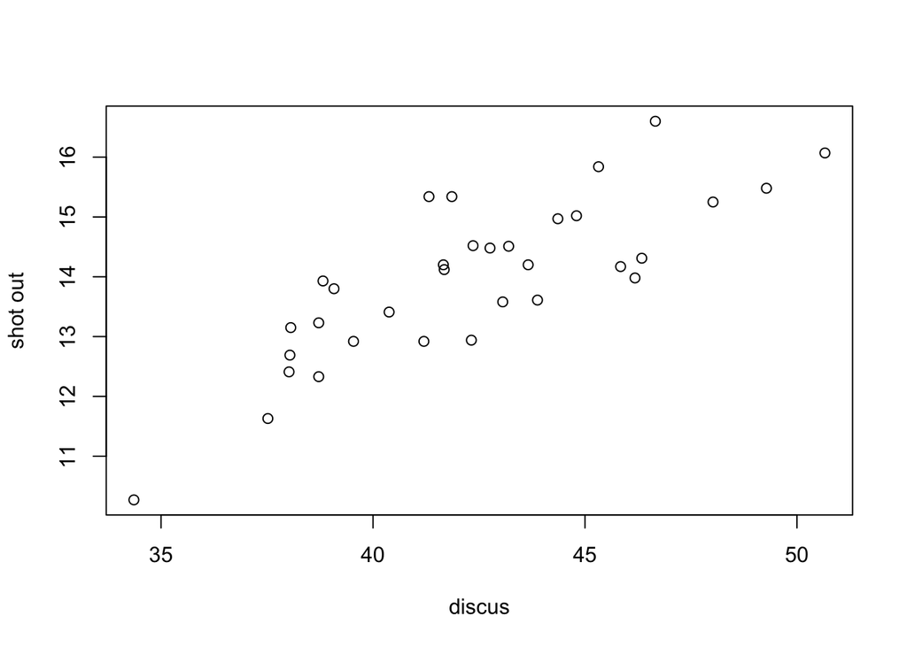

```r
plot(decath$disq, decath$poid,
     xlab = "discus", ylab = "shot out")
```

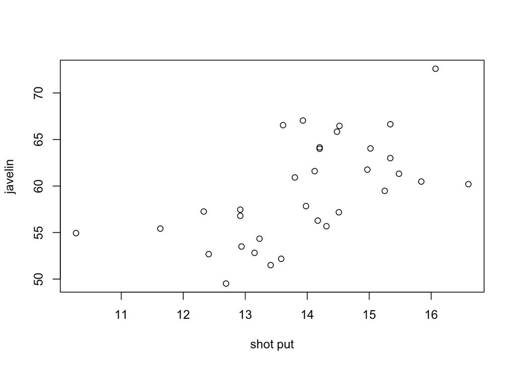

```r
plot(decath$poid, decath$jave,
     xlab = "shot put", ylab = "javelin")
```

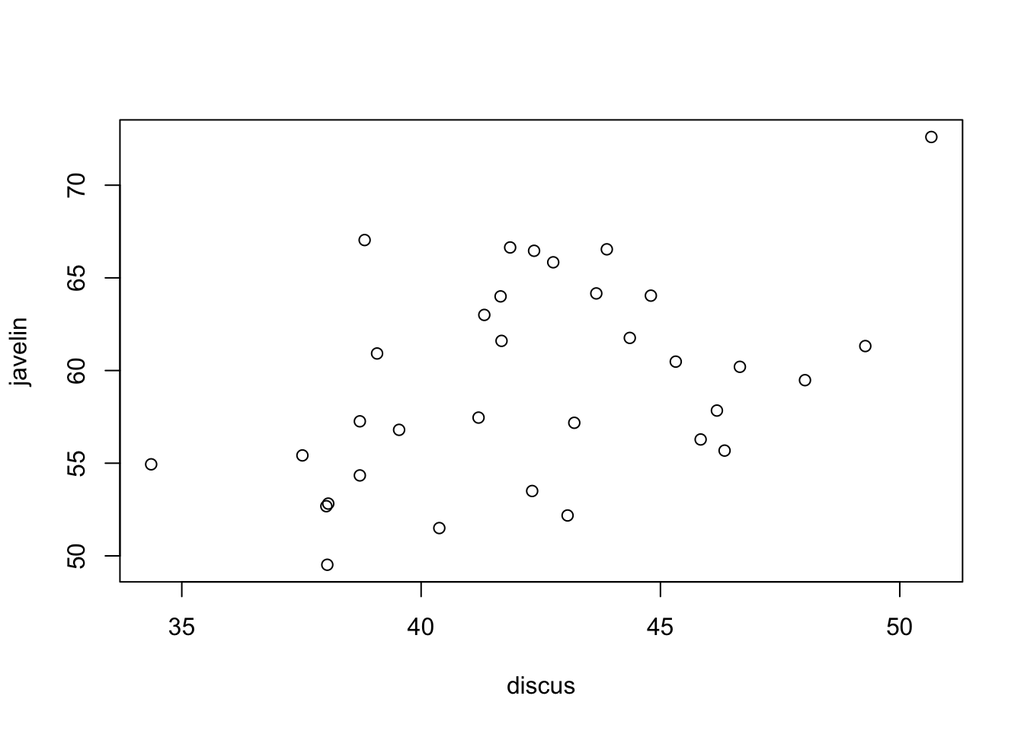

```r
plot(decath$disq, decath$jave,
     xlab = "discus", ylab = "javelin")
```

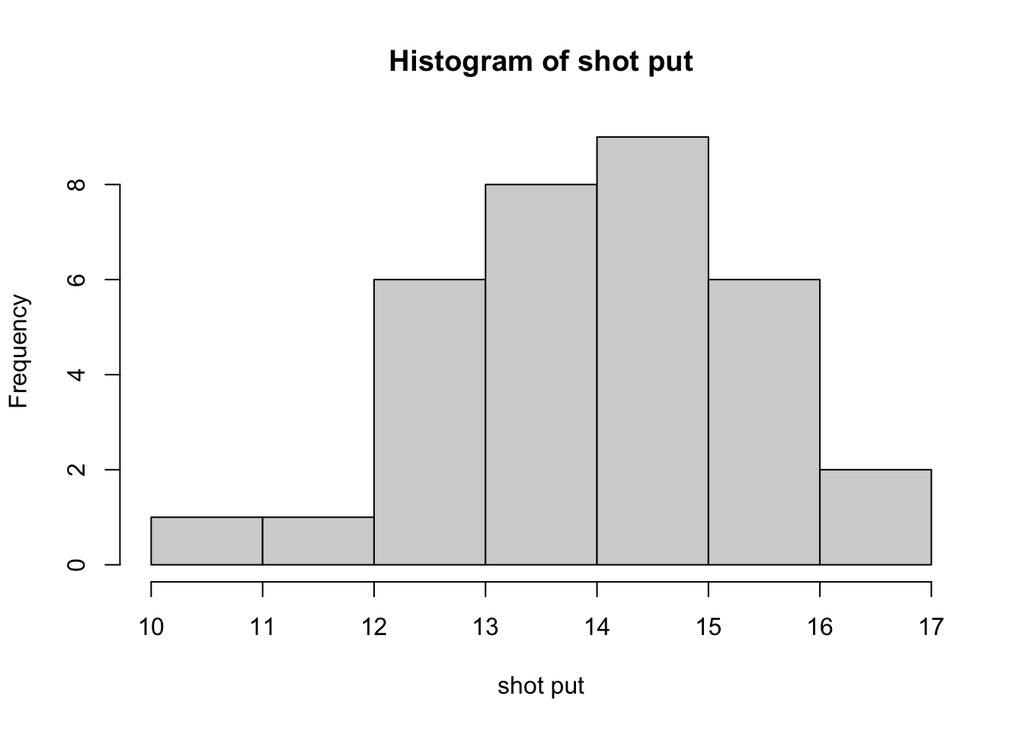

```r
hist(decath$poid, xlab = "shot put", main = "Histogram of shot put")
```

6. Use `mfrow` or `mfcol` to create a two-by-two plotting array and then plot all four of the above plots in one window.

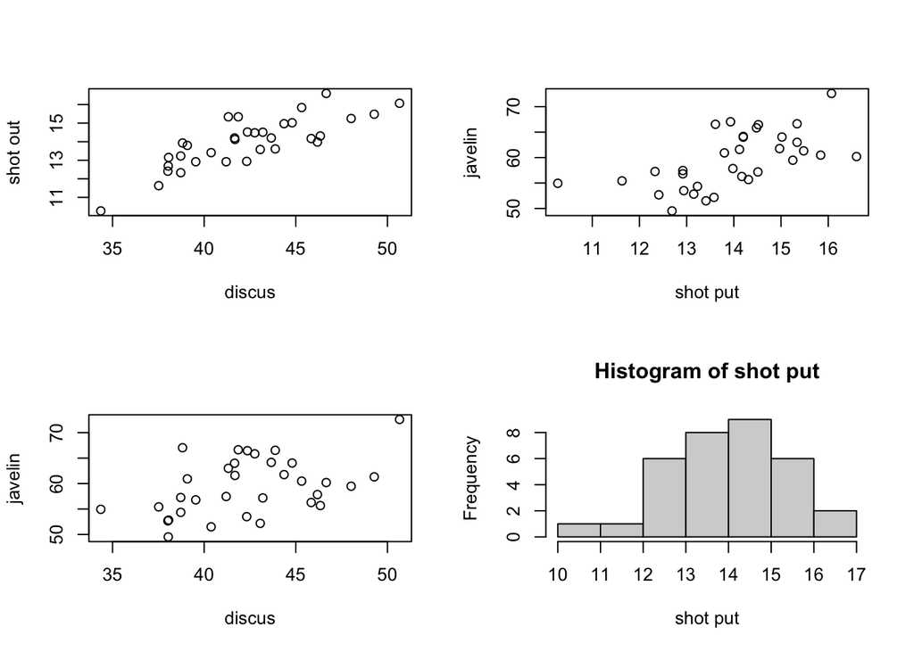

```r
par(mfrow = c(2, 2))
plot(decath$disq, decath$poid,
     xlab = "discus", ylab = "shot out")
plot(decath$poid, decath$jave,
     xlab = "shot put", ylab = "javelin")
plot(decath$disq, decath$jave,
     xlab = "discus", ylab = "javelin")
hist(decath$poid, xlab = "shot put", main = "Histogram of shot put")
```

7. Use function `ggMarginal` in package *ggExtra* to create a scatterplot of discus(disq) vs shot put(poid) with marginal density curves.

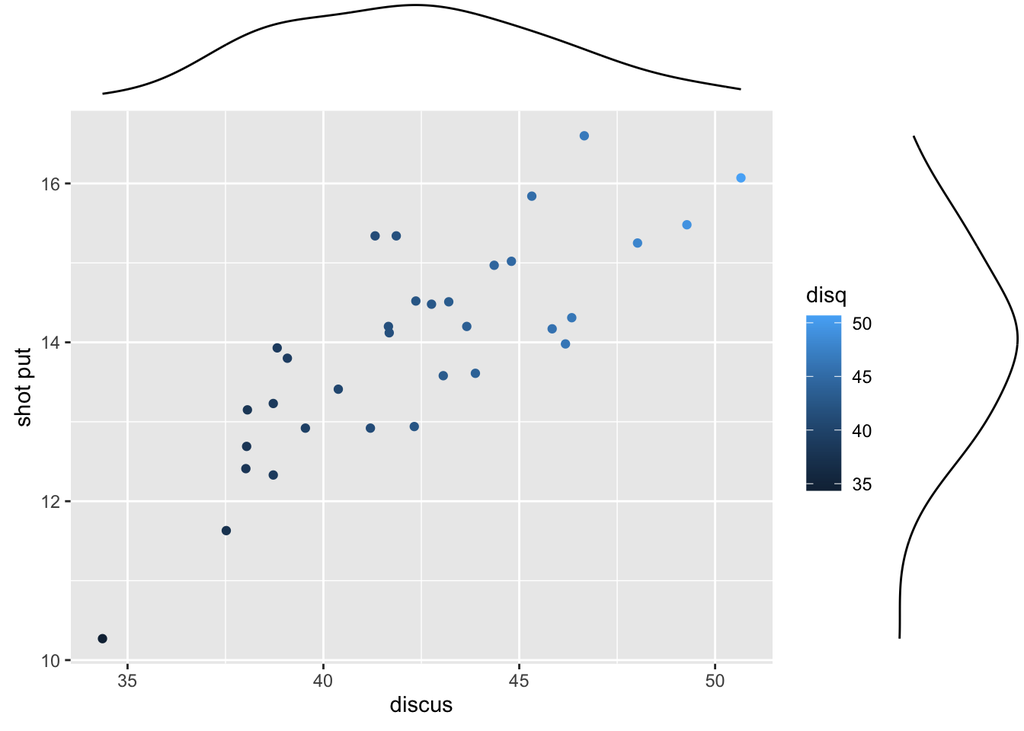

```r
library(ggExtra)
scatter <- decath %>%
  ggplot(aes(x = disq, y = poid)) +
  geom_point(aes(color = disq)) +
  xlab("discus") +
  ylab("shot put")
mar <- ggMarginal(scatter, groupColour = FALSE)
mar
```

## Part 2 MORE ON DATA TRANSFORMATIONS

1. Import or load the acupuncture data we used last week and, once again, call it `acu`.

```r
acu <- read.csv("acupuncture.csv")
```

2. Create a new version of the data called `acu2` that are sorted by treatment group, sex, and age, in that order, so that the group variable has all 0s first and all 1s next, the sex variable is sorted 0/1 within levels of the group variable, and age is sorted last within combinations of the two categorical variables.

```r
acu2 <- acu %>%
  arrange(group, sex, age)
acu2
```

```
##      id age sex migraine chronicity acupuncturist group   pk1      pk5
## 1   432  18   0        1         16             3     0 18.50  9.75000
## 2   773  25   0        1          6            11     0 15.50 22.50000
## 3   266  27   0        1          8             3     0 18.25  0.25000
## 4   188  29   0        1          4             9     0 14.75  9.25000
## 5   621  37   0        1         20             8     0 23.25 16.00000
## 6   339  41   0        1         21            11     0 32.25 42.75000
## 7   676  42   0        1          5             2     0 16.50  3.50000
## 8   205  44   0        1         10             2     0 30.00 29.50000
## 9   467  46   0        1         19             9     0 63.75 71.50000
## 10  333  47   0        1         39             8     0  6.75 12.00000
## 11  277  48   0        1         25            11     0 66.50 29.75000
## 12  470  49   0        1         24             9     0 36.25 46.75000
## 13  452  50   0        1         36             9     0 20.00 19.75000
## 14  521  50   0        1         10             3     0 11.50  7.50000
```

[output cut: 287 more lines]

```r
acu3 <- acu %>%
  filter(age > 30)
acu3
```

```
##      id age sex migraine chronicity acupuncturist group   pk1      pk5
## 1   104  32   1        1         14            12     0 16.00 15.33333
## 2   108  56   1        1         40             9     0 16.50 23.25000
## 3   112  45   1        1         27             9     1  9.25  6.25000
## 4   113  45   1        1         30             9     1 42.50 51.25000
## 5   114  49   1        1         49             9     1 24.25 25.25000
## 6   126  47   1        1         42             5     0 21.00 15.25000
## 7   130  46   1        1          3             7     1 21.75  1.00000
## 8   131  64   1        1         23             7     1 14.50  2.50000
## 9   135  59   1        1         40             7     0 40.50 28.75000
## 10  137  53   1        1         32             7     1 11.75 13.50000
## 11  141  37   1        0          7             7     1 15.50  2.75000
## 12  143  51   0        1         38             7     0 33.25 26.75000
## 13  144  49   1        1         10             7     0 39.50 40.00000
## 14  148  55   1        1         20             2     0 20.50 32.75000
```

[output cut: 257 more lines]

4. Create a subset of the original data called `acu4` that only includes participants who had baseline severity at or above the 40th percentile of baseline severity scores.

```r
# acu4 <- acu %>%
#   filter(ntile(pk1, n = 5) > 2)
acu4 <- acu %>%
  filter(pk1 > quantile(acu$pk1, probs = .4))
acu4
```

```
##      id age sex migraine chronicity acupuncturist group   pk1      pk5
## 1   113  45   1        1         30             9     1 42.50 51.25000
## 2   114  49   1        1         49             9     1 24.25 25.25000
## 3   126  47   1        1         42             5     0 21.00 15.25000
## 4   130  46   1        1          3             7     1 21.75  1.00000
## 5   135  59   1        1         40             7     0 40.50 28.75000
## 6   143  51   0        1         38             7     0 33.25 26.75000
## 7   144  49   1        1         10             7     0 39.50 40.00000
## 8   148  55   1        1         20             2     0 20.50 32.75000
## 9   149  23   1        1         23             2     1 49.25 19.50000
## 10  161  32   1        1          5             5     1 59.75 38.00000
## 11  169  49   1        1         40             5     1 19.75 18.75000
## 12  183  63   1        1         20             9     0 55.75 62.25000
## 13  184  46   1        1         15             9     1 23.50  9.75000
## 14  185  36   1        1          4             7     1 21.00 15.50000
```

[output cut: 166 more lines]

5. Use `which()` to note which rows of the original data correspond with participants that are female and 40 years of age or older.

```r
## female is not "female", female = 1
rows <- acu[which(acu$sex == 1 & acu$age >= 40), ]
rows
```

```
##      id age sex migraine chronicity acupuncturist group   pk1      pk5
## 2   108  56   1        1         40             9     0 16.50 23.25000
## 3   112  45   1        1         27             9     1  9.25  6.25000
## 4   113  45   1        1         30             9     1 42.50 51.25000
## 5   114  49   1        1         49             9     1 24.25 25.25000
## 6   126  47   1        1         42             5     0 21.00 15.25000
## 7   130  46   1        1          3             7     1 21.75  1.00000
## 8   131  64   1        1         23             7     1 14.50  2.50000
## 9   135  59   1        1         40             7     0 40.50 28.75000
## 10  137  53   1        1         32             7     1 11.75 13.50000
## 13  144  49   1        1         10             7     0 39.50 40.00000
## 14  148  55   1        1         20             2     0 20.50 32.75000
## 16  150  59   1        1         54             2     1  9.75 21.50000
## 18  162  47   1        1          4             5     0 14.50 12.50000
## 19  169  49   1        1         40             5     1 19.75 18.75000
```

[output cut: 181 more lines]